# Risk Factor Analysis

## Outcome Variable

**Outcome Variable:** sstunted

## Predictor Variables

**Intervention Variable:** enstunt

**Adjustment Set:**

unadjusted

## Stratifying Variables

The analysis was stratified on these variable(s):

- agecat
- studyid
- country

## Data Summary

| agecat | studyid | country | enstunt | sstunted | n_cell | n |
| --- | --- | --- | --- | --- | --- | --- |
| Birth | ki0047075b-MAL-ED | BANGLADESH | 0 | 0 | 210 | 257 |
| Birth | ki0047075b-MAL-ED | BANGLADESH | 0 | 1 | 0 | 257 |
| Birth | ki0047075b-MAL-ED | BANGLADESH | 1 | 0 | 38 | 257 |
| Birth | ki0047075b-MAL-ED | BANGLADESH | 1 | 1 | 9 | 257 |
| Birth | ki0047075b-MAL-ED | BRAZIL | 0 | 0 | 170 | 191 |
| Birth | ki0047075b-MAL-ED | BRAZIL | 0 | 1 | 0 | 191 |
| Birth | ki0047075b-MAL-ED | BRAZIL | 1 | 0 | 13 | 191 |
| Birth | ki0047075b-MAL-ED | BRAZIL | 1 | 1 | 8 | 191 |
| Birth | ki0047075b-MAL-ED | INDIA | 0 | 0 | 173 | 206 |
| Birth | ki0047075b-MAL-ED | INDIA | 0 | 1 | 0 | 206 |
| Birth | ki0047075b-MAL-ED | INDIA | 1 | 0 | 26 | 206 |
| Birth | ki0047075b-MAL-ED | INDIA | 1 | 1 | 7 | 206 |
| Birth | ki0047075b-MAL-ED | NEPAL | 0 | 0 | 155 | 173 |
| Birth | ki0047075b-MAL-ED | NEPAL | 0 | 1 | 0 | 173 |
| Birth | ki0047075b-MAL-ED | NEPAL | 1 | 0 | 12 | 173 |
| Birth | ki0047075b-MAL-ED | NEPAL | 1 | 1 | 6 | 173 |
| Birth | ki0047075b-MAL-ED | PERU | 0 | 0 | 253 | 287 |
| Birth | ki0047075b-MAL-ED | PERU | 0 | 1 | 0 | 287 |
| Birth | ki0047075b-MAL-ED | PERU | 1 | 0 | 26 | 287 |
| Birth | ki0047075b-MAL-ED | PERU | 1 | 1 | 8 | 287 |
| Birth | ki0047075b-MAL-ED | SOUTH AFRICA | 0 | 0 | 234 | 262 |
| Birth | ki0047075b-MAL-ED | SOUTH AFRICA | 0 | 1 | 0 | 262 |
| Birth | ki0047075b-MAL-ED | SOUTH AFRICA | 1 | 0 | 26 | 262 |
| Birth | ki0047075b-MAL-ED | SOUTH AFRICA | 1 | 1 | 2 | 262 |
| Birth | ki0047075b-MAL-ED | TANZANIA, UNITED REPUBLIC OF | 0 | 0 | 105 | 123 |
| Birth | ki0047075b-MAL-ED | TANZANIA, UNITED REPUBLIC OF | 0 | 1 | 0 | 123 |
| Birth | ki0047075b-MAL-ED | TANZANIA, UNITED REPUBLIC OF | 1 | 0 | 12 | 123 |
| Birth | ki0047075b-MAL-ED | TANZANIA, UNITED REPUBLIC OF | 1 | 1 | 6 | 123 |
| Birth | ki1000108-CMC-V-BCS-2002 | INDIA | 0 | 0 | 74 | 90 |
| Birth | ki1000108-CMC-V-BCS-2002 | INDIA | 0 | 1 | 0 | 90 |

[output cut: 314 more lines]

The following strata were considered:

- agecat: 24 months, studyid: ki0047075b-MAL-ED, country: BANGLADESH
- agecat: 24 months, studyid: ki0047075b-MAL-ED, country: BRAZIL
- agecat: 24 months, studyid: ki0047075b-MAL-ED, country: INDIA
- agecat: 24 months, studyid: ki0047075b-MAL-ED, country: NEPAL
- agecat: 24 months, studyid: ki0047075b-MAL-ED, country: PERU
- agecat: 24 months, studyid: ki0047075b-MAL-ED, country: SOUTH AFRICA
- agecat: 24 months, studyid: ki0047075b-MAL-ED, country: TANZANIA, UNITED REPUBLIC OF
- agecat: 24 months, studyid: ki1000108-CMC-V-BCS-2002, country: INDIA
- agecat: 24 months, studyid: ki1000108-IRC, country: INDIA
- agecat: 24 months, studyid: ki1017093-NIH-Birth, country: BANGLADESH
- agecat: 24 months, studyid: ki1017093b-PROVIDE, country: BANGLADESH
- agecat: 24 months, studyid: ki1017093c-NIH-Crypto, country: BANGLADESH
- agecat: 24 months, studyid: ki1066203-TanzaniaChild2, country: TANZANIA, UNITED REPUBLIC OF
- agecat: 24 months, studyid: ki1101329-Keneba, country: GAMBIA
- agecat: 24 months, studyid: ki1113344-GMS-Nepal, country: NEPAL
- agecat: 24 months, studyid: ki1114097-CMIN, country: BANGLADESH
- agecat: 24 months, studyid: ki1114097-CMIN, country: GUINEA-BISSAU
- agecat: 24 months, studyid: ki1114097-CMIN, country: PERU
- agecat: 24 months, studyid: ki1114097-CONTENT, country: PERU
- agecat: 24 months, studyid: ki1119695-PROBIT, country: BELARUS
- agecat: 24 months, studyid: ki1126311-ZVITAMBO, country: ZIMBABWE
- agecat: 24 months, studyid: ki1135781-COHORTS, country: GUATEMALA
- agecat: 24 months, studyid: ki1135781-COHORTS, country: INDIA
- agecat: 24 months, studyid: ki1135781-COHORTS, country: PHILIPPINES
- agecat: 24 months, studyid: ki1148112-LCNI-5, country: MALAWI
- agecat: 24 months, studyid: kiGH5241-JiVitA-3, country: BANGLADESH
- agecat: 24 months, studyid: kiGH5241-JiVitA-4, country: BANGLADESH
- agecat: 6 months, studyid: ki0047075b-MAL-ED, country: BANGLADESH
- agecat: 6 months, studyid: ki0047075b-MAL-ED, country: BRAZIL
- agecat: 6 months, studyid: ki0047075b-MAL-ED, country: INDIA
- agecat: 6 months, studyid: ki0047075b-MAL-ED, country: NEPAL
- agecat: 6 months, studyid: ki0047075b-MAL-ED, country: PERU
- agecat: 6 months, studyid: ki0047075b-MAL-ED, country: SOUTH AFRICA
- agecat: 6 months, studyid: ki0047075b-MAL-ED, country: TANZANIA, UNITED REPUBLIC OF
- agecat: 6 months, studyid: ki1000108-CMC-V-BCS-2002, country: INDIA
- agecat: 6 months, studyid: ki1000108-IRC, country: INDIA
- agecat: 6 months, studyid: ki1000109-EE, country: PAKISTAN
- agecat: 6 months, studyid: ki1000109-ResPak, country: PAKISTAN
- agecat: 6 months, studyid: ki1000304b-SAS-CompFeed, country: INDIA
- agecat: 6 months, studyid: ki1000304b-SAS-FoodSuppl, country: INDIA
- agecat: 6 months, studyid: ki1017093-NIH-Birth, country: BANGLADESH
- agecat: 6 months, studyid: ki1017093b-PROVIDE, country: BANGLADESH
- agecat: 6 months, studyid: ki1017093c-NIH-Crypto, country: BANGLADESH
- agecat: 6 months, studyid: ki1066203-TanzaniaChild2, country: TANZANIA, UNITED REPUBLIC OF
- agecat: 6 months, studyid: ki1101329-Keneba, country: GAMBIA
- agecat: 6 months, studyid: ki1112895-Guatemala BSC, country: GUATEMALA
- agecat: 6 months, studyid: ki1113344-GMS-Nepal, country: NEPAL
- agecat: 6 months, studyid: ki1114097-CMIN, country: BANGLADESH
- agecat: 6 months, studyid: ki1114097-CMIN, country: BRAZIL
- agecat: 6 months, studyid: ki1114097-CMIN, country: GUINEA-BISSAU
- agecat: 6 months, studyid: ki1114097-CMIN, country: PERU
- agecat: 6 months, studyid: ki1114097-CONTENT, country: PERU
- agecat: 6 months, studyid: ki1119695-PROBIT, country: BELARUS
- agecat: 6 months, studyid: ki1126311-ZVITAMBO, country: ZIMBABWE
- agecat: 6 months, studyid: ki1135781-COHORTS, country: GUATEMALA
- agecat: 6 months, studyid: ki1135781-COHORTS, country: INDIA
- agecat: 6 months, studyid: ki1135781-COHORTS, country: PHILIPPINES
- agecat: 6 months, studyid: ki1148112-LCNI-5, country: MALAWI
- agecat: 6 months, studyid: kiGH5241-JiVitA-3, country: BANGLADESH
- agecat: 6 months, studyid: kiGH5241-JiVitA-4, country: BANGLADESH
- agecat: Birth, studyid: ki0047075b-MAL-ED, country: BANGLADESH
- agecat: Birth, studyid: ki0047075b-MAL-ED, country: BRAZIL
- agecat: Birth, studyid: ki0047075b-MAL-ED, country: INDIA
- agecat: Birth, studyid: ki0047075b-MAL-ED, country: NEPAL
- agecat: Birth, studyid: ki0047075b-MAL-ED, country: PERU
- agecat: Birth, studyid: ki0047075b-MAL-ED, country: SOUTH AFRICA
- agecat: Birth, studyid: ki0047075b-MAL-ED, country: TANZANIA, UNITED REPUBLIC OF
- agecat: Birth, studyid: ki1000108-CMC-V-BCS-2002, country: INDIA
- agecat: Birth, studyid: ki1000108-IRC, country: INDIA
- agecat: Birth, studyid: ki1000109-EE, country: PAKISTAN
- agecat: Birth, studyid: ki1000109-ResPak, country: PAKISTAN
- agecat: Birth, studyid: ki1000304b-SAS-CompFeed, country: INDIA
- agecat: Birth, studyid: ki1017093-NIH-Birth, country: BANGLADESH
- agecat: Birth, studyid: ki1017093c-NIH-Crypto, country: BANGLADESH
- agecat: Birth, studyid: ki1101329-Keneba, country: GAMBIA
- agecat: Birth, studyid: ki1114097-CMIN, country: BANGLADESH
- agecat: Birth, studyid: ki1114097-CMIN, country: BRAZIL
- agecat: Birth, studyid: ki1114097-CMIN, country: PERU
- agecat: Birth, studyid: ki1114097-CONTENT, country: PERU
- agecat: Birth, studyid: ki1119695-PROBIT, country: BELARUS
- agecat: Birth, studyid: ki1126311-ZVITAMBO, country: ZIMBABWE
- agecat: Birth, studyid: ki1135781-COHORTS, country: GUATEMALA
- agecat: Birth, studyid: ki1135781-COHORTS, country: INDIA
- agecat: Birth, studyid: ki1135781-COHORTS, country: PHILIPPINES
- agecat: Birth, studyid: kiGH5241-JiVitA-3, country: BANGLADESH
- agecat: Birth, studyid: kiGH5241-JiVitA-4, country: BANGLADESH

### Dropped Strata

Some strata were dropped due to rare outcomes:

- agecat: Birth, studyid: ki0047075b-MAL-ED, country: BANGLADESH
- agecat: Birth, studyid: ki0047075b-MAL-ED, country: BRAZIL
- agecat: Birth, studyid: ki0047075b-MAL-ED, country: INDIA
- agecat: Birth, studyid: ki0047075b-MAL-ED, country: NEPAL
- agecat: Birth, studyid: ki0047075b-MAL-ED, country: PERU
- agecat: Birth, studyid: ki0047075b-MAL-ED, country: SOUTH AFRICA
- agecat: Birth, studyid: ki0047075b-MAL-ED, country: TANZANIA, UNITED REPUBLIC OF
- agecat: Birth, studyid: ki1000108-CMC-V-BCS-2002, country: INDIA
- agecat: Birth, studyid: ki1000108-IRC, country: INDIA
- agecat: Birth, studyid: ki1000109-EE, country: PAKISTAN
- agecat: Birth, studyid: ki1000109-ResPak, country: PAKISTAN
- agecat: Birth, studyid: ki1000304b-SAS-CompFeed, country: INDIA
- agecat: Birth, studyid: ki1017093-NIH-Birth, country: BANGLADESH
- agecat: Birth, studyid: ki1017093c-NIH-Crypto, country: BANGLADESH
- agecat: Birth, studyid: ki1101329-Keneba, country: GAMBIA
- agecat: Birth, studyid: ki1114097-CMIN, country: BANGLADESH
- agecat: Birth, studyid: ki1114097-CMIN, country: BRAZIL
- agecat: Birth, studyid: ki1114097-CMIN, country: PERU
- agecat: Birth, studyid: ki1114097-CONTENT, country: PERU
- agecat: Birth, studyid: ki1119695-PROBIT, country: BELARUS
- agecat: Birth, studyid: ki1126311-ZVITAMBO, country: ZIMBABWE
- agecat: Birth, studyid: ki1135781-COHORTS, country: GUATEMALA
- agecat: Birth, studyid: ki1135781-COHORTS, country: INDIA
- agecat: Birth, studyid: ki1135781-COHORTS, country: PHILIPPINES
- agecat: Birth, studyid: kiGH5241-JiVitA-3, country: BANGLADESH
- agecat: Birth, studyid: kiGH5241-JiVitA-4, country: BANGLADESH
- agecat: 6 months, studyid: ki0047075b-MAL-ED, country: BANGLADESH
- agecat: 6 months, studyid: ki0047075b-MAL-ED, country: BRAZIL
- agecat: 6 months, studyid: ki0047075b-MAL-ED, country: INDIA
- agecat: 6 months, studyid: ki0047075b-MAL-ED, country: NEPAL
- agecat: 6 months, studyid: ki0047075b-MAL-ED, country: PERU
- agecat: 6 months, studyid: ki0047075b-MAL-ED, country: SOUTH AFRICA
- agecat: 6 months, studyid: ki1000304b-SAS-FoodSuppl, country: INDIA
- agecat: 6 months, studyid: ki1112895-Guatemala BSC, country: GUATEMALA
- agecat: 6 months, studyid: ki1114097-CMIN, country: BANGLADESH
- agecat: 6 months, studyid: ki1114097-CMIN, country: BRAZIL
- agecat: 6 months, studyid: ki1114097-CMIN, country: GUINEA-BISSAU
- agecat: 6 months, studyid: ki1114097-CMIN, country: PERU
- agecat: 6 months, studyid: ki1114097-CONTENT, country: PERU
- agecat: 6 months, studyid: ki1148112-LCNI-5, country: MALAWI
- agecat: 24 months, studyid: ki0047075b-MAL-ED, country: BRAZIL
- agecat: 24 months, studyid: ki0047075b-MAL-ED, country: NEPAL
- agecat: 24 months, studyid: ki0047075b-MAL-ED, country: SOUTH AFRICA
- agecat: 24 months, studyid: ki1066203-TanzaniaChild2, country: TANZANIA, UNITED REPUBLIC OF
- agecat: 24 months, studyid: ki1114097-CONTENT, country: PERU
- agecat: 24 months, studyid: ki1119695-PROBIT, country: BELARUS

## Methods Detail

We’re interested in the causal parameters $E[Y_a]$ for all values of $a \in \mathcal{A}$. These parameters represent the mean outcome if, possibly contrary to fact, we intervened to set all units to have $A=a$. Under the randomization and positivity assumptions, these are identified by the statistical parameters $\psi_a=E_W[E_{Y|A,W}(Y|A=a,W)]$. In addition, we’re interested in the mean of $Y$, $E[Y]$ under no intervention (the observed mean). We will estimate these parameters by using SuperLearner to fit the relevant likelihood factors – $E_{Y|A,W}(Y|A=a,W)$ and $p(A=a|W)$, and then updating our likelihood fit using a joint TMLE.

For unadjusted analyses ($W=\{\}$), initial likelihoods were estimated using Lrnr_glm to estimate the simple $E(Y|A)$ and Lrnr_mean to estimate $p(A)$. For adjusted analyses, a small library containing Lrnr_glmnet, Lrnr_xgboost, and Lrnr_mean was used.

Having estimated these parameters, we will then use the delta method to estimate relative risks and attributable risks relative to a prespecified baseline level of $A$.

# Results Detail

## Results Plots

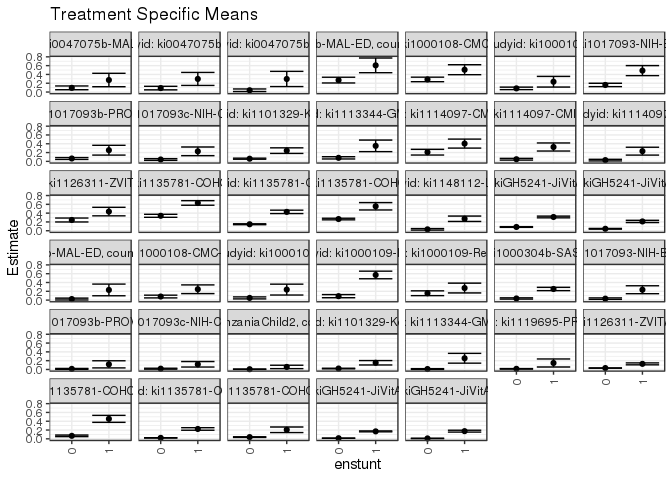

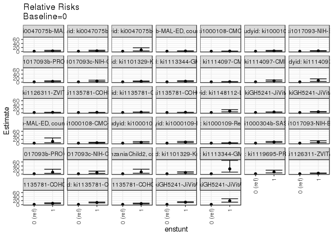

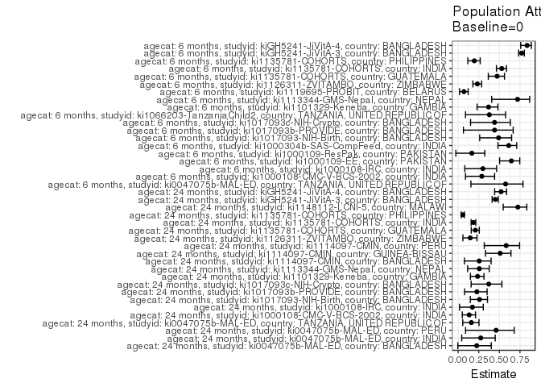

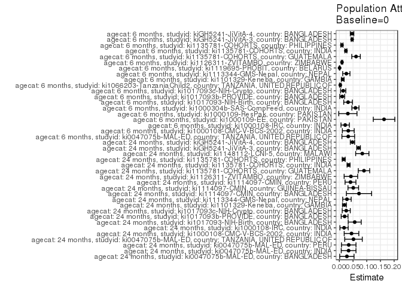

## Results Table

### Parameter: TSM

| agecat | studyid | country | intervention_level | baseline_level | estimate | ci_lower | ci_upper |
| --- | --- | --- | --- | --- | --- | --- | --- |
| 6 months | ki0047075b-MAL-ED | TANZANIA, UNITED REPUBLIC OF | 0 | NA | 0.0240385 | 0.0031807 | 0.0448962 |
| 6 months | ki0047075b-MAL-ED | TANZANIA, UNITED REPUBLIC OF | 1 | NA | 0.2307692 | 0.0982698 | 0.3632687 |
| 6 months | ki1000108-CMC-V-BCS-2002 | INDIA | 0 | NA | 0.0810811 | 0.0499431 | 0.1122190 |
| 6 months | ki1000108-CMC-V-BCS-2002 | INDIA | 1 | NA | 0.2465753 | 0.1475673 | 0.3455834 |
| 6 months | ki1000108-IRC | INDIA | 0 | NA | 0.0498615 | 0.0273811 | 0.0723419 |
| 6 months | ki1000108-IRC | INDIA | 1 | NA | 0.2391304 | 0.1157132 | 0.3625477 |
| 6 months | ki1000109-EE | PAKISTAN | 0 | NA | 0.0894309 | 0.0537229 | 0.1251389 |
| 6 months | ki1000109-EE | PAKISTAN | 1 | NA | 0.5714286 | 0.4849039 | 0.6579532 |
| 6 months | ki1000109-ResPak | PAKISTAN | 0 | NA | 0.1560694 | 0.1018739 | 0.2102649 |
| 6 months | ki1000109-ResPak | PAKISTAN | 1 | NA | 0.2741935 | 0.1629135 | 0.3854736 |
| 6 months | ki1000304b-SAS-CompFeed | INDIA | 0 | NA | 0.0370370 | 0.0224368 | 0.0516373 |
| 6 months | ki1000304b-SAS-CompFeed | INDIA | 1 | NA | 0.2527473 | 0.2155600 | 0.2899345 |
| 6 months | ki1017093-NIH-Birth | BANGLADESH | 0 | NA | 0.0331858 | 0.0166574 | 0.0497143 |
| 6 months | ki1017093-NIH-Birth | BANGLADESH | 1 | NA | 0.2352941 | 0.1450340 | 0.3255543 |
| 6 months | ki1017093b-PROVIDE | BANGLADESH | 0 | NA | 0.0133843 | 0.0035274 | 0.0232413 |
| 6 months | ki1017093b-PROVIDE | BANGLADESH | 1 | NA | 0.1166667 | 0.0353685 | 0.1979649 |
| 6 months | ki1017093c-NIH-Crypto | BANGLADESH | 0 | NA | 0.0179445 | 0.0074284 | 0.0284607 |
| 6 months | ki1017093c-NIH-Crypto | BANGLADESH | 1 | NA | 0.1176471 | 0.0550774 | 0.1802167 |
| 6 months | ki1066203-TanzaniaChild2 | TANZANIA, UNITED REPUBLIC OF | 0 | NA | 0.0058201 | 0.0023899 | 0.0092503 |
| 6 months | ki1066203-TanzaniaChild2 | TANZANIA, UNITED REPUBLIC OF | 1 | NA | 0.0575540 | 0.0188270 | 0.0962809 |
| 6 months | ki1101329-Keneba | GAMBIA | 0 | NA | 0.0211416 | 0.0146580 | 0.0276253 |
| 6 months | ki1101329-Keneba | GAMBIA | 1 | NA | 0.1522843 | 0.1020995 | 0.2024690 |
| 6 months | ki1113344-GMS-Nepal | NEPAL | 0 | NA | 0.0099206 | 0.0012605 | 0.0185807 |
| 6 months | ki1113344-GMS-Nepal | NEPAL | 1 | NA | 0.2542373 | 0.1430313 | 0.3654433 |
| 6 months | ki1119695-PROBIT | BELARUS | 0 | NA | 0.0143296 | 0.0091070 | 0.0195522 |
| 6 months | ki1119695-PROBIT | BELARUS | 1 | NA | 0.1472868 | 0.0560408 | 0.2385328 |
| 6 months | ki1126311-ZVITAMBO | ZIMBABWE | 0 | NA | 0.0319635 | 0.0279678 | 0.0359591 |
| 6 months | ki1126311-ZVITAMBO | ZIMBABWE | 1 | NA | 0.1272085 | 0.1047937 | 0.1496232 |
| 6 months | ki1135781-COHORTS | GUATEMALA | 0 | NA | 0.0679852 | 0.0506304 | 0.0853399 |
| 6 months | ki1135781-COHORTS | GUATEMALA | 1 | NA | 0.4539474 | 0.3747570 | 0.5331377 |
| 6 months | ki1135781-COHORTS | INDIA | 0 | NA | 0.0213294 | 0.0176879 | 0.0249709 |
| 6 months | ki1135781-COHORTS | INDIA | 1 | NA | 0.2241379 | 0.1954531 | 0.2528227 |
| 6 months | ki1135781-COHORTS | PHILIPPINES | 0 | NA | 0.0391850 | 0.0316554 | 0.0467145 |
| 6 months | ki1135781-COHORTS | PHILIPPINES | 1 | NA | 0.2051282 | 0.1417519 | 0.2685046 |
| 6 months | kiGH5241-JiVitA-3 | BANGLADESH | 0 | NA | 0.0138918 | 0.0115363 | 0.0162474 |
| 6 months | kiGH5241-JiVitA-3 | BANGLADESH | 1 | NA | 0.1692384 | 0.1586442 | 0.1798325 |
| 6 months | kiGH5241-JiVitA-4 | BANGLADESH | 0 | NA | 0.0091297 | 0.0053339 | 0.0129256 |
| 6 months | kiGH5241-JiVitA-4 | BANGLADESH | 1 | NA | 0.1743705 | 0.1531306 | 0.1956105 |
| 24 months | ki0047075b-MAL-ED | BANGLADESH | 0 | NA | 0.0949721 | 0.0519217 | 0.1380225 |
| 24 months | ki0047075b-MAL-ED | BANGLADESH | 1 | NA | 0.2727273 | 0.1204165 | 0.4250381 |
| 24 months | ki0047075b-MAL-ED | INDIA | 0 | NA | 0.0894737 | 0.0487990 | 0.1301483 |
| 24 months | ki0047075b-MAL-ED | INDIA | 1 | NA | 0.2972973 | 0.1496970 | 0.4448976 |
| 24 months | ki0047075b-MAL-ED | PERU | 0 | NA | 0.0402299 | 0.0109604 | 0.0694993 |
| 24 months | ki0047075b-MAL-ED | PERU | 1 | NA | 0.2962963 | 0.1236301 | 0.4689625 |
| 24 months | ki0047075b-MAL-ED | TANZANIA, UNITED REPUBLIC OF | 0 | NA | 0.2707182 | 0.2058350 | 0.3356014 |
| 24 months | ki0047075b-MAL-ED | TANZANIA, UNITED REPUBLIC OF | 1 | NA | 0.6060606 | 0.4389589 | 0.7731623 |
| 24 months | ki1000108-CMC-V-BCS-2002 | INDIA | 0 | NA | 0.2861953 | 0.2347228 | 0.3376678 |
| 24 months | ki1000108-CMC-V-BCS-2002 | INDIA | 1 | NA | 0.5066667 | 0.3933658 | 0.6199676 |
| 24 months | ki1000108-IRC | INDIA | 0 | NA | 0.0828729 | 0.0544384 | 0.1113075 |
| 24 months | ki1000108-IRC | INDIA | 1 | NA | 0.2340426 | 0.1128487 | 0.3552364 |
| 24 months | ki1017093-NIH-Birth | BANGLADESH | 0 | NA | 0.1605634 | 0.1223287 | 0.1987981 |
| 24 months | ki1017093-NIH-Birth | BANGLADESH | 1 | NA | 0.4864865 | 0.3724746 | 0.6004984 |
| 24 months | ki1017093b-PROVIDE | BANGLADESH | 0 | NA | 0.0656371 | 0.0442923 | 0.0869819 |
| 24 months | ki1017093b-PROVIDE | BANGLADESH | 1 | NA | 0.2542373 | 0.1430337 | 0.3654409 |
| 24 months | ki1017093c-NIH-Crypto | BANGLADESH | 0 | NA | 0.0427928 | 0.0239490 | 0.0616366 |
| 24 months | ki1017093c-NIH-Crypto | BANGLADESH | 1 | NA | 0.2285714 | 0.1301067 | 0.3270362 |
| 24 months | ki1101329-Keneba | GAMBIA | 0 | NA | 0.0606843 | 0.0487913 | 0.0725773 |
| 24 months | ki1101329-Keneba | GAMBIA | 1 | NA | 0.2443182 | 0.1808194 | 0.3078169 |
| 24 months | ki1113344-GMS-Nepal | NEPAL | 0 | NA | 0.0803571 | 0.0551591 | 0.1055552 |
| 24 months | ki1113344-GMS-Nepal | NEPAL | 1 | NA | 0.3529412 | 0.2216542 | 0.4842282 |
| 24 months | ki1114097-CMIN | BANGLADESH | 0 | NA | 0.2091503 | 0.1445733 | 0.2737273 |
| 24 months | ki1114097-CMIN | BANGLADESH | 1 | NA | 0.4044944 | 0.3023178 | 0.5066710 |
| 24 months | ki1114097-CMIN | GUINEA-BISSAU | 0 | NA | 0.0488889 | 0.0289474 | 0.0688304 |
| 24 months | ki1114097-CMIN | GUINEA-BISSAU | 1 | NA | 0.3267327 | 0.2351798 | 0.4182855 |
| 24 months | ki1114097-CMIN | PERU | 0 | NA | 0.0291545 | 0.0113293 | 0.0469798 |
| 24 months | ki1114097-CMIN | PERU | 1 | NA | 0.2325581 | 0.1431671 | 0.3219492 |
| 24 months | ki1126311-ZVITAMBO | ZIMBABWE | 0 | NA | 0.2443820 | 0.1996947 | 0.2890694 |
| 24 months | ki1126311-ZVITAMBO | ZIMBABWE | 1 | NA | 0.4356436 | 0.3388369 | 0.5324503 |
| 24 months | ki1135781-COHORTS | GUATEMALA | 0 | NA | 0.3396226 | 0.3055314 | 0.3737139 |
| 24 months | ki1135781-COHORTS | GUATEMALA | 1 | NA | 0.6314199 | 0.5794249 | 0.6834149 |
| 24 months | ki1135781-COHORTS | INDIA | 0 | NA | 0.1476910 | 0.1375458 | 0.1578362 |
| 24 months | ki1135781-COHORTS | INDIA | 1 | NA | 0.4290172 | 0.3906987 | 0.4673357 |
| 24 months | ki1135781-COHORTS | PHILIPPINES | 0 | NA | 0.2658009 | 0.2477825 | 0.2838193 |
| 24 months | ki1135781-COHORTS | PHILIPPINES | 1 | NA | 0.5555556 | 0.4717172 | 0.6393939 |
| 24 months | ki1148112-LCNI-5 | MALAWI | 0 | NA | 0.0318302 | 0.0140945 | 0.0495659 |
| 24 months | ki1148112-LCNI-5 | MALAWI | 1 | NA | 0.2722772 | 0.2108393 | 0.3337151 |
| 24 months | kiGH5241-JiVitA-3 | BANGLADESH | 0 | NA | 0.0855534 | 0.0776178 | 0.0934890 |
| 24 months | kiGH5241-JiVitA-3 | BANGLADESH | 1 | NA | 0.3127464 | 0.2936164 | 0.3318764 |
| 24 months | kiGH5241-JiVitA-4 | BANGLADESH | 0 | NA | 0.0441288 | 0.0357556 | 0.0525019 |
| 24 months | kiGH5241-JiVitA-4 | BANGLADESH | 1 | NA | 0.2114951 | 0.1866568 | 0.2363334 |

### Parameter: E(Y)

| agecat | studyid | country | intervention_level | baseline_level | estimate | ci_lower | ci_upper |
| --- | --- | --- | --- | --- | --- | --- | --- |
| 6 months | ki0047075b-MAL-ED | TANZANIA, UNITED REPUBLIC OF | NA | NA | 0.0566802 | 0.0277850 | 0.0855754 |
| 6 months | ki1000108-CMC-V-BCS-2002 | INDIA | NA | NA | 0.1138211 | 0.0813725 | 0.1462698 |
| 6 months | ki1000108-IRC | INDIA | NA | NA | 0.0712531 | 0.0462303 | 0.0962759 |
| 6 months | ki1000109-EE | PAKISTAN | NA | NA | 0.2526882 | 0.2084696 | 0.2969067 |
| 6 months | ki1000109-ResPak | PAKISTAN | NA | NA | 0.1872340 | 0.1372518 | 0.2372162 |
| 6 months | ki1000304b-SAS-CompFeed | INDIA | NA | NA | 0.0958084 | 0.0774939 | 0.1141229 |
| 6 months | ki1017093-NIH-Birth | BANGLADESH | NA | NA | 0.0651769 | 0.0442802 | 0.0860736 |
| 6 months | ki1017093b-PROVIDE | BANGLADESH | NA | NA | 0.0240137 | 0.0115761 | 0.0364514 |
| 6 months | ki1017093c-NIH-Crypto | BANGLADESH | NA | NA | 0.0321678 | 0.0192256 | 0.0451101 |
| 6 months | ki1066203-TanzaniaChild2 | TANZANIA, UNITED REPUBLIC OF | NA | NA | 0.0093642 | 0.0051724 | 0.0135561 |
| 6 months | ki1101329-Keneba | GAMBIA | NA | NA | 0.0335089 | 0.0257898 | 0.0412279 |
| 6 months | ki1113344-GMS-Nepal | NEPAL | NA | NA | 0.0355240 | 0.0202206 | 0.0508273 |
| 6 months | ki1119695-PROBIT | BELARUS | NA | NA | 0.0154178 | 0.0100323 | 0.0208033 |
| 6 months | ki1126311-ZVITAMBO | ZIMBABWE | NA | NA | 0.0417119 | 0.0374091 | 0.0460146 |
| 6 months | ki1135781-COHORTS | GUATEMALA | NA | NA | 0.1290323 | 0.1078261 | 0.1502384 |
| 6 months | ki1135781-COHORTS | INDIA | NA | NA | 0.0453353 | 0.0404119 | 0.0502586 |
| 6 months | ki1135781-COHORTS | PHILIPPINES | NA | NA | 0.0487445 | 0.0406327 | 0.0568562 |
| 6 months | kiGH5241-JiVitA-3 | BANGLADESH | NA | NA | 0.0606665 | 0.0568133 | 0.0645198 |
| 6 months | kiGH5241-JiVitA-4 | BANGLADESH | NA | NA | 0.0556496 | 0.0487560 | 0.0625432 |
| 24 months | ki0047075b-MAL-ED | BANGLADESH | NA | NA | 0.1226415 | 0.0783812 | 0.1669018 |
| 24 months | ki0047075b-MAL-ED | INDIA | NA | NA | 0.1233480 | 0.0804760 | 0.1662200 |
| 24 months | ki0047075b-MAL-ED | PERU | NA | NA | 0.0746269 | 0.0382069 | 0.1110468 |
| 24 months | ki0047075b-MAL-ED | TANZANIA, UNITED REPUBLIC OF | NA | NA | 0.3224299 | 0.2596598 | 0.3852000 |
| 24 months | ki1000108-CMC-V-BCS-2002 | INDIA | NA | NA | 0.3306452 | 0.2827744 | 0.3785159 |
| 24 months | ki1000108-IRC | INDIA | NA | NA | 0.1002445 | 0.0711031 | 0.1293859 |
| 24 months | ki1017093-NIH-Birth | BANGLADESH | NA | NA | 0.2167832 | 0.1777459 | 0.2558205 |
| 24 months | ki1017093b-PROVIDE | BANGLADESH | NA | NA | 0.0849220 | 0.0621566 | 0.1076874 |
| 24 months | ki1017093c-NIH-Crypto | BANGLADESH | NA | NA | 0.0680934 | 0.0462948 | 0.0898920 |
| 24 months | ki1101329-Keneba | GAMBIA | NA | NA | 0.0794203 | 0.0666566 | 0.0921840 |
| 24 months | ki1113344-GMS-Nepal | NEPAL | NA | NA | 0.1082164 | 0.0809323 | 0.1355005 |
| 24 months | ki1114097-CMIN | BANGLADESH | NA | NA | 0.2809917 | 0.2242434 | 0.3377401 |
| 24 months | ki1114097-CMIN | GUINEA-BISSAU | NA | NA | 0.0998185 | 0.0747668 | 0.1248702 |
| 24 months | ki1114097-CMIN | PERU | NA | NA | 0.0699301 | 0.0457690 | 0.0940911 |
| 24 months | ki1126311-ZVITAMBO | ZIMBABWE | NA | NA | 0.2866521 | 0.2451477 | 0.3281565 |
| 24 months | ki1135781-COHORTS | GUATEMALA | NA | NA | 0.4296365 | 0.4000034 | 0.4592696 |
| 24 months | ki1135781-COHORTS | INDIA | NA | NA | 0.1814607 | 0.1711228 | 0.1917985 |
| 24 months | ki1135781-COHORTS | PHILIPPINES | NA | NA | 0.2817996 | 0.2639639 | 0.2996353 |
| 24 months | ki1148112-LCNI-5 | MALAWI | NA | NA | 0.1157168 | 0.0896385 | 0.1417950 |
| 24 months | kiGH5241-JiVitA-3 | BANGLADESH | NA | NA | 0.1558110 | 0.1470514 | 0.1645706 |
| 24 months | kiGH5241-JiVitA-4 | BANGLADESH | NA | NA | 0.0921436 | 0.0826637 | 0.1016234 |

### Parameter: RR

| agecat | studyid | country | intervention_level | baseline_level | estimate | ci_lower | ci_upper |
| --- | --- | --- | --- | --- | --- | --- | --- |
| 6 months | ki0047075b-MAL-ED | TANZANIA, UNITED REPUBLIC OF | 0 | 0 | 1.000000 | 1.000000 | 1.000000 |
| 6 months | ki0047075b-MAL-ED | TANZANIA, UNITED REPUBLIC OF | 1 | 0 | 9.600000 | 3.391639 | 27.172702 |
| 6 months | ki1000108-CMC-V-BCS-2002 | INDIA | 0 | 0 | 1.000000 | 1.000000 | 1.000000 |
| 6 months | ki1000108-CMC-V-BCS-2002 | INDIA | 1 | 0 | 3.041096 | 1.744730 | 5.300683 |
| 6 months | ki1000108-IRC | INDIA | 0 | 0 | 1.000000 | 1.000000 | 1.000000 |
| 6 months | ki1000108-IRC | INDIA | 1 | 0 | 4.795894 | 2.416830 | 9.516845 |
| 6 months | ki1000109-EE | PAKISTAN | 0 | 0 | 1.000000 | 1.000000 | 1.000000 |
| 6 months | ki1000109-EE | PAKISTAN | 1 | 0 | 6.389610 | 4.168875 | 9.793318 |
| 6 months | ki1000109-ResPak | PAKISTAN | 0 | 0 | 1.000000 | 1.000000 | 1.000000 |
| 6 months | ki1000109-ResPak | PAKISTAN | 1 | 0 | 1.756870 | 1.029841 | 2.997154 |
| 6 months | ki1000304b-SAS-CompFeed | INDIA | 0 | 0 | 1.000000 | 1.000000 | 1.000000 |
| 6 months | ki1000304b-SAS-CompFeed | INDIA | 1 | 0 | 6.824176 | 4.815626 | 9.670472 |
| 6 months | ki1017093-NIH-Birth | BANGLADESH | 0 | 0 | 1.000000 | 1.000000 | 1.000000 |
| 6 months | ki1017093-NIH-Birth | BANGLADESH | 1 | 0 | 7.090196 | 3.781243 | 13.294804 |
| 6 months | ki1017093b-PROVIDE | BANGLADESH | 0 | 0 | 1.000000 | 1.000000 | 1.000000 |
| 6 months | ki1017093b-PROVIDE | BANGLADESH | 1 | 0 | 8.716667 | 3.162480 | 24.025537 |
| 6 months | ki1017093c-NIH-Crypto | BANGLADESH | 0 | 0 | 1.000000 | 1.000000 | 1.000000 |
| 6 months | ki1017093c-NIH-Crypto | BANGLADESH | 1 | 0 | 6.556150 | 2.971351 | 14.465843 |
| 6 months | ki1066203-TanzaniaChild2 | TANZANIA, UNITED REPUBLIC OF | 0 | 0 | 1.000000 | 1.000000 | 1.000000 |
| 6 months | ki1066203-TanzaniaChild2 | TANZANIA, UNITED REPUBLIC OF | 1 | 0 | 9.888816 | 4.042664 | 24.189171 |
| 6 months | ki1101329-Keneba | GAMBIA | 0 | 0 | 1.000000 | 1.000000 | 1.000000 |
| 6 months | ki1101329-Keneba | GAMBIA | 1 | 0 | 7.203046 | 4.592090 | 11.298531 |
| 6 months | ki1113344-GMS-Nepal | NEPAL | 0 | 0 | 1.000000 | 1.000000 | 1.000000 |
| 6 months | ki1113344-GMS-Nepal | NEPAL | 1 | 0 | 25.627119 | 9.652859 | 68.036752 |
| 6 months | ki1119695-PROBIT | BELARUS | 0 | 0 | 1.000000 | 1.000000 | 1.000000 |
| 6 months | ki1119695-PROBIT | BELARUS | 1 | 0 | 10.278516 | 5.493149 | 19.232663 |
| 6 months | ki1126311-ZVITAMBO | ZIMBABWE | 0 | 0 | 1.000000 | 1.000000 | 1.000000 |
| 6 months | ki1126311-ZVITAMBO | ZIMBABWE | 1 | 0 | 3.979808 | 3.206533 | 4.939563 |
| 6 months | ki1135781-COHORTS | GUATEMALA | 0 | 0 | 1.000000 | 1.000000 | 1.000000 |
| 6 months | ki1135781-COHORTS | GUATEMALA | 1 | 0 | 6.677153 | 4.901323 | 9.096396 |
| 6 months | ki1135781-COHORTS | INDIA | 0 | 0 | 1.000000 | 1.000000 | 1.000000 |
| 6 months | ki1135781-COHORTS | INDIA | 1 | 0 | 10.508420 | 8.489312 | 13.007755 |
| 6 months | ki1135781-COHORTS | PHILIPPINES | 0 | 0 | 1.000000 | 1.000000 | 1.000000 |
| 6 months | ki1135781-COHORTS | PHILIPPINES | 1 | 0 | 5.234872 | 3.638251 | 7.532159 |
| 6 months | kiGH5241-JiVitA-3 | BANGLADESH | 0 | 0 | 1.000000 | 1.000000 | 1.000000 |
| 6 months | kiGH5241-JiVitA-3 | BANGLADESH | 1 | 0 | 12.182567 | 10.195738 | 14.556568 |
| 6 months | kiGH5241-JiVitA-4 | BANGLADESH | 0 | 0 | 1.000000 | 1.000000 | 1.000000 |
| 6 months | kiGH5241-JiVitA-4 | BANGLADESH | 1 | 0 | 19.099199 | 12.355021 | 29.524791 |
| 24 months | ki0047075b-MAL-ED | BANGLADESH | 0 | 0 | 1.000000 | 1.000000 | 1.000000 |
| 24 months | ki0047075b-MAL-ED | BANGLADESH | 1 | 0 | 2.871658 | 1.398788 | 5.895404 |
| 24 months | ki0047075b-MAL-ED | INDIA | 0 | 0 | 1.000000 | 1.000000 | 1.000000 |
| 24 months | ki0047075b-MAL-ED | INDIA | 1 | 0 | 3.322735 | 1.694905 | 6.513974 |
| 24 months | ki0047075b-MAL-ED | PERU | 0 | 0 | 1.000000 | 1.000000 | 1.000000 |
| 24 months | ki0047075b-MAL-ED | PERU | 1 | 0 | 7.365079 | 2.899635 | 18.707319 |
| 24 months | ki0047075b-MAL-ED | TANZANIA, UNITED REPUBLIC OF | 0 | 0 | 1.000000 | 1.000000 | 1.000000 |
| 24 months | ki0047075b-MAL-ED | TANZANIA, UNITED REPUBLIC OF | 1 | 0 | 2.238714 | 1.553603 | 3.225947 |
| 24 months | ki1000108-CMC-V-BCS-2002 | INDIA | 0 | 0 | 1.000000 | 1.000000 | 1.000000 |
| 24 months | ki1000108-CMC-V-BCS-2002 | INDIA | 1 | 0 | 1.770353 | 1.328709 | 2.358793 |
| 24 months | ki1000108-IRC | INDIA | 0 | 0 | 1.000000 | 1.000000 | 1.000000 |
| 24 months | ki1000108-IRC | INDIA | 1 | 0 | 2.824114 | 1.517417 | 5.256048 |
| 24 months | ki1017093-NIH-Birth | BANGLADESH | 0 | 0 | 1.000000 | 1.000000 | 1.000000 |
| 24 months | ki1017093-NIH-Birth | BANGLADESH | 1 | 0 | 3.029872 | 2.169315 | 4.231808 |
| 24 months | ki1017093b-PROVIDE | BANGLADESH | 0 | 0 | 1.000000 | 1.000000 | 1.000000 |
| 24 months | ki1017093b-PROVIDE | BANGLADESH | 1 | 0 | 3.873380 | 2.245853 | 6.680344 |
| 24 months | ki1017093c-NIH-Crypto | BANGLADESH | 0 | 0 | 1.000000 | 1.000000 | 1.000000 |
| 24 months | ki1017093c-NIH-Crypto | BANGLADESH | 1 | 0 | 5.341353 | 2.884808 | 9.889760 |
| 24 months | ki1101329-Keneba | GAMBIA | 0 | 0 | 1.000000 | 1.000000 | 1.000000 |
| 24 months | ki1101329-Keneba | GAMBIA | 1 | 0 | 4.026052 | 2.907445 | 5.575031 |
| 24 months | ki1113344-GMS-Nepal | NEPAL | 0 | 0 | 1.000000 | 1.000000 | 1.000000 |
| 24 months | ki1113344-GMS-Nepal | NEPAL | 1 | 0 | 4.392157 | 2.700140 | 7.144459 |
| 24 months | ki1114097-CMIN | BANGLADESH | 0 | 0 | 1.000000 | 1.000000 | 1.000000 |
| 24 months | ki1114097-CMIN | BANGLADESH | 1 | 0 | 1.933989 | 1.297787 | 2.882069 |
| 24 months | ki1114097-CMIN | GUINEA-BISSAU | 0 | 0 | 1.000000 | 1.000000 | 1.000000 |
| 24 months | ki1114097-CMIN | GUINEA-BISSAU | 1 | 0 | 6.683168 | 4.074407 | 10.962267 |
| 24 months | ki1114097-CMIN | PERU | 0 | 0 | 1.000000 | 1.000000 | 1.000000 |
| 24 months | ki1114097-CMIN | PERU | 1 | 0 | 7.976744 | 3.874182 | 16.423713 |
| 24 months | ki1126311-ZVITAMBO | ZIMBABWE | 0 | 0 | 1.000000 | 1.000000 | 1.000000 |
| 24 months | ki1126311-ZVITAMBO | ZIMBABWE | 1 | 0 | 1.782633 | 1.336845 | 2.377076 |
| 24 months | ki1135781-COHORTS | GUATEMALA | 0 | 0 | 1.000000 | 1.000000 | 1.000000 |
| 24 months | ki1135781-COHORTS | GUATEMALA | 1 | 0 | 1.859181 | 1.632809 | 2.116938 |
| 24 months | ki1135781-COHORTS | INDIA | 0 | 0 | 1.000000 | 1.000000 | 1.000000 |
| 24 months | ki1135781-COHORTS | INDIA | 1 | 0 | 2.904829 | 2.595288 | 3.251290 |
| 24 months | ki1135781-COHORTS | PHILIPPINES | 0 | 0 | 1.000000 | 1.000000 | 1.000000 |
| 24 months | ki1135781-COHORTS | PHILIPPINES | 1 | 0 | 2.090119 | 1.771428 | 2.466146 |
| 24 months | ki1148112-LCNI-5 | MALAWI | 0 | 0 | 1.000000 | 1.000000 | 1.000000 |
| 24 months | ki1148112-LCNI-5 | MALAWI | 1 | 0 | 8.554043 | 4.689153 | 15.604449 |
| 24 months | kiGH5241-JiVitA-3 | BANGLADESH | 0 | 0 | 1.000000 | 1.000000 | 1.000000 |
| 24 months | kiGH5241-JiVitA-3 | BANGLADESH | 1 | 0 | 3.655569 | 3.282352 | 4.071223 |
| 24 months | kiGH5241-JiVitA-4 | BANGLADESH | 0 | 0 | 1.000000 | 1.000000 | 1.000000 |
| 24 months | kiGH5241-JiVitA-4 | BANGLADESH | 1 | 0 | 4.792682 | 3.820794 | 6.011788 |

### Parameter: PAR

| agecat | studyid | country | intervention_level | baseline_level | estimate | ci_lower | ci_upper |
| --- | --- | --- | --- | --- | --- | --- | --- |
| 6 months | ki0047075b-MAL-ED | TANZANIA, UNITED REPUBLIC OF | 0 | NA | 0.0326417 | 0.0094626 | 0.0558208 |
| 6 months | ki1000108-CMC-V-BCS-2002 | INDIA | 0 | NA | 0.0327401 | 0.0111306 | 0.0543495 |
| 6 months | ki1000108-IRC | INDIA | 0 | NA | 0.0213916 | 0.0060617 | 0.0367215 |
| 6 months | ki1000109-EE | PAKISTAN | 0 | NA | 0.1632573 | 0.1239639 | 0.2025507 |
| 6 months | ki1000109-ResPak | PAKISTAN | 0 | NA | 0.0311647 | -0.0021652 | 0.0644946 |
| 6 months | ki1000304b-SAS-CompFeed | INDIA | 0 | NA | 0.0587713 | 0.0458331 | 0.0717096 |
| 6 months | ki1017093-NIH-Birth | BANGLADESH | 0 | NA | 0.0319911 | 0.0161807 | 0.0478014 |
| 6 months | ki1017093b-PROVIDE | BANGLADESH | 0 | NA | 0.0106294 | 0.0018240 | 0.0194348 |
| 6 months | ki1017093c-NIH-Crypto | BANGLADESH | 0 | NA | 0.0142233 | 0.0048177 | 0.0236289 |
| 6 months | ki1066203-TanzaniaChild2 | TANZANIA, UNITED REPUBLIC OF | 0 | NA | 0.0035441 | 0.0008206 | 0.0062676 |
| 6 months | ki1101329-Keneba | GAMBIA | 0 | NA | 0.0123672 | 0.0073200 | 0.0174144 |
| 6 months | ki1113344-GMS-Nepal | NEPAL | 0 | NA | 0.0256033 | 0.0123778 | 0.0388288 |
| 6 months | ki1119695-PROBIT | BELARUS | 0 | NA | 0.0010882 | 0.0002614 | 0.0019150 |
| 6 months | ki1126311-ZVITAMBO | ZIMBABWE | 0 | NA | 0.0097484 | 0.0073367 | 0.0121601 |
| 6 months | ki1135781-COHORTS | GUATEMALA | 0 | NA | 0.0610471 | 0.0454333 | 0.0766609 |
| 6 months | ki1135781-COHORTS | INDIA | 0 | NA | 0.0240059 | 0.0202485 | 0.0277633 |
| 6 months | ki1135781-COHORTS | PHILIPPINES | 0 | NA | 0.0095595 | 0.0056049 | 0.0135141 |
| 6 months | kiGH5241-JiVitA-3 | BANGLADESH | 0 | NA | 0.0467747 | 0.0433332 | 0.0502162 |
| 6 months | kiGH5241-JiVitA-4 | BANGLADESH | 0 | NA | 0.0465199 | 0.0401069 | 0.0529328 |
| 24 months | ki0047075b-MAL-ED | BANGLADESH | 0 | NA | 0.0276694 | 0.0015425 | 0.0537964 |
| 24 months | ki0047075b-MAL-ED | INDIA | 0 | NA | 0.0338743 | 0.0069874 | 0.0607613 |
| 24 months | ki0047075b-MAL-ED | PERU | 0 | NA | 0.0343970 | 0.0079419 | 0.0608520 |
| 24 months | ki0047075b-MAL-ED | TANZANIA, UNITED REPUBLIC OF | 0 | NA | 0.0517117 | 0.0196396 | 0.0837838 |
| 24 months | ki1000108-CMC-V-BCS-2002 | INDIA | 0 | NA | 0.0444499 | 0.0177946 | 0.0711052 |
| 24 months | ki1000108-IRC | INDIA | 0 | NA | 0.0173716 | 0.0023210 | 0.0324221 |
| 24 months | ki1017093-NIH-Birth | BANGLADESH | 0 | NA | 0.0562198 | 0.0324216 | 0.0800181 |
| 24 months | ki1017093b-PROVIDE | BANGLADESH | 0 | NA | 0.0192849 | 0.0068015 | 0.0317684 |
| 24 months | ki1017093c-NIH-Crypto | BANGLADESH | 0 | NA | 0.0253006 | 0.0105762 | 0.0400249 |
| 24 months | ki1101329-Keneba | GAMBIA | 0 | NA | 0.0187360 | 0.0116416 | 0.0258304 |
| 24 months | ki1113344-GMS-Nepal | NEPAL | 0 | NA | 0.0278593 | 0.0123910 | 0.0433276 |
| 24 months | ki1114097-CMIN | BANGLADESH | 0 | NA | 0.0718414 | 0.0258249 | 0.1178579 |
| 24 months | ki1114097-CMIN | GUINEA-BISSAU | 0 | NA | 0.0509296 | 0.0315463 | 0.0703129 |
| 24 months | ki1114097-CMIN | PERU | 0 | NA | 0.0407756 | 0.0209410 | 0.0606101 |
| 24 months | ki1126311-ZVITAMBO | ZIMBABWE | 0 | NA | 0.0422701 | 0.0176056 | 0.0669345 |
| 24 months | ki1135781-COHORTS | GUATEMALA | 0 | NA | 0.0900139 | 0.0692065 | 0.1108213 |
| 24 months | ki1135781-COHORTS | INDIA | 0 | NA | 0.0337697 | 0.0284166 | 0.0391227 |
| 24 months | ki1135781-COHORTS | PHILIPPINES | 0 | NA | 0.0159987 | 0.0105855 | 0.0214119 |
| 24 months | ki1148112-LCNI-5 | MALAWI | 0 | NA | 0.0838865 | 0.0596997 | 0.1080733 |
| 24 months | kiGH5241-JiVitA-3 | BANGLADESH | 0 | NA | 0.0702576 | 0.0635810 | 0.0769342 |
| 24 months | kiGH5241-JiVitA-4 | BANGLADESH | 0 | NA | 0.0480148 | 0.0400919 | 0.0559377 |

### Parameter: PAF

| agecat | studyid | country | intervention_level | baseline_level | estimate | ci_lower | ci_upper |
| --- | --- | --- | --- | --- | --- | --- | --- |
| 6 months | ki0047075b-MAL-ED | TANZANIA, UNITED REPUBLIC OF | 0 | NA | 0.5758929 | 0.1551277 | 0.7871076 |
| 6 months | ki1000108-CMC-V-BCS-2002 | INDIA | 0 | NA | 0.2876448 | 0.0895472 | 0.4426400 |
| 6 months | ki1000108-IRC | INDIA | 0 | NA | 0.3002197 | 0.0810070 | 0.4671423 |
| 6 months | ki1000109-EE | PAKISTAN | 0 | NA | 0.6460820 | 0.5028934 | 0.7480260 |
| 6 months | ki1000109-ResPak | PAKISTAN | 0 | NA | 0.1664477 | -0.0277394 | 0.3239440 |
| 6 months | ki1000304b-SAS-CompFeed | INDIA | 0 | NA | 0.6134259 | 0.4830009 | 0.7109482 |
| 6 months | ki1017093-NIH-Birth | BANGLADESH | 0 | NA | 0.4908344 | 0.2615395 | 0.6489323 |
| 6 months | ki1017093b-PROVIDE | BANGLADESH | 0 | NA | 0.4426386 | 0.0644328 | 0.6679536 |
| 6 months | ki1017093c-NIH-Crypto | BANGLADESH | 0 | NA | 0.4421590 | 0.1505775 | 0.6336492 |
| 6 months | ki1066203-TanzaniaChild2 | TANZANIA, UNITED REPUBLIC OF | 0 | NA | 0.3784740 | 0.0897894 | 0.5755986 |
| 6 months | ki1101329-Keneba | GAMBIA | 0 | NA | 0.3690728 | 0.2301006 | 0.4829595 |
| 6 months | ki1113344-GMS-Nepal | NEPAL | 0 | NA | 0.7207341 | 0.4071824 | 0.8684428 |
| 6 months | ki1119695-PROBIT | BELARUS | 0 | NA | 0.0705822 | 0.0164597 | 0.1217265 |
| 6 months | ki1126311-ZVITAMBO | ZIMBABWE | 0 | NA | 0.2337081 | 0.1789171 | 0.2848429 |
| 6 months | ki1135781-COHORTS | GUATEMALA | 0 | NA | 0.4731150 | 0.3657983 | 0.5622720 |
| 6 months | ki1135781-COHORTS | INDIA | 0 | NA | 0.5295195 | 0.4644904 | 0.5866518 |
| 6 months | ki1135781-COHORTS | PHILIPPINES | 0 | NA | 0.1961148 | 0.1176543 | 0.2675983 |
| 6 months | kiGH5241-JiVitA-3 | BANGLADESH | 0 | NA | 0.7710130 | 0.7338333 | 0.8029992 |
| 6 months | kiGH5241-JiVitA-4 | BANGLADESH | 0 | NA | 0.8359426 | 0.7592012 | 0.8882269 |
| 24 months | ki0047075b-MAL-ED | BANGLADESH | 0 | NA | 0.2256124 | -0.0032028 | 0.4022383 |
| 24 months | ki0047075b-MAL-ED | INDIA | 0 | NA | 0.2746241 | 0.0434695 | 0.4499179 |
| 24 months | ki0047075b-MAL-ED | PERU | 0 | NA | 0.4609195 | 0.0905879 | 0.6804444 |
| 24 months | ki0047075b-MAL-ED | TANZANIA, UNITED REPUBLIC OF | 0 | NA | 0.1603811 | 0.0558926 | 0.2533055 |
| 24 months | ki1000108-CMC-V-BCS-2002 | INDIA | 0 | NA | 0.1344338 | 0.0503185 | 0.2110988 |
| 24 months | ki1000108-IRC | INDIA | 0 | NA | 0.1732920 | 0.0170865 | 0.3046732 |
| 24 months | ki1017093-NIH-Birth | BANGLADESH | 0 | NA | 0.2593367 | 0.1479652 | 0.3561505 |
| 24 months | ki1017093b-PROVIDE | BANGLADESH | 0 | NA | 0.2270901 | 0.0786610 | 0.3516070 |
| 24 months | ki1017093c-NIH-Crypto | BANGLADESH | 0 | NA | 0.3715573 | 0.1575911 | 0.5311775 |
| 24 months | ki1101329-Keneba | GAMBIA | 0 | NA | 0.2359092 | 0.1492971 | 0.3137032 |
| 24 months | ki1113344-GMS-Nepal | NEPAL | 0 | NA | 0.2574405 | 0.1150105 | 0.3769478 |
| 24 months | ki1114097-CMIN | BANGLADESH | 0 | NA | 0.2556709 | 0.0767711 | 0.3999042 |
| 24 months | ki1114097-CMIN | GUINEA-BISSAU | 0 | NA | 0.5102222 | 0.3320495 | 0.6408682 |
| 24 months | ki1114097-CMIN | PERU | 0 | NA | 0.5830904 | 0.3167840 | 0.7455949 |
| 24 months | ki1126311-ZVITAMBO | ZIMBABWE | 0 | NA | 0.1474612 | 0.0578527 | 0.2285469 |
| 24 months | ki1135781-COHORTS | GUATEMALA | 0 | NA | 0.2095117 | 0.1591313 | 0.2568736 |
| 24 months | ki1135781-COHORTS | INDIA | 0 | NA | 0.1860991 | 0.1573472 | 0.2138701 |
| 24 months | ki1135781-COHORTS | PHILIPPINES | 0 | NA | 0.0567734 | 0.0374565 | 0.0757027 |
| 24 months | ki1148112-LCNI-5 | MALAWI | 0 | NA | 0.7249297 | 0.5464658 | 0.8331688 |
| 24 months | kiGH5241-JiVitA-3 | BANGLADESH | 0 | NA | 0.4509154 | 0.4122614 | 0.4870273 |
| 24 months | kiGH5241-JiVitA-4 | BANGLADESH | 0 | NA | 0.5210868 | 0.4432465 | 0.5880442 |